# HW5 : 석사 2학기 이동규

### **Library**

```r
library(tidyverse)
library(lubridate)
library(aRxiv)
library(topicmodels) # lda
library(tidytext)
library(tidyverse)
library(scales) # ggplot scale
library(e1071) # svm
library(randomForest) # randomforest
library(caret) # confusion matrix
library(Epi)   # ROC, AUC
library(MLmetrics) # F1 score
```

### **Data Import**

```r
rm(list=ls())
gc()
```

```
##           used  (Mb) gc trigger  (Mb) max used  (Mb)
## Ncells 2208320 118.0    4441602 237.3  2987495 159.6
## Vcells 3681511  28.1    8388608  64.0  6470703  49.4
```

```r
# bio <- arxiv_search(query = '"biology"', limit = 1000)
# write.csv(bio,file='bio.csv') # write csv.
# adm <- arxiv_search(query = '"administration"', limit = 1000)
# write.csv(adm,file='adm.csv') # write csv.

bio <- read.csv('C:\\Users\\82104\\Desktop\\bio.csv') # data import
bio <- bio[,-1] %>%
  as_tibble()
adm <- read.csv('C:\\Users\\82104\\Desktop\\adm.csv') # data import
adm <- adm[,-1] %>%
  as_tibble()
```

## 1. Combine two data sets with additional categroical variable that represents the source, bio or adm.

```r
bio <- bio %>%
  select(title,abstract) %>%
  as_tibble() %>%
  mutate(title=as.character.Date(title),
         abstract=as.character.Date(abstract),
         category='bio')
adm <- adm %>%
  select(title,abstract) %>%
  as_tibble() %>%
  mutate(title=as.character.Date(title),
         abstract=as.character.Date(abstract),
         category='adm')

data <- bio %>%
  bind_rows(adm)

data
```

```
## # A tibble: 2,000 x 3
##    title                           abstract                        category
##    <chr>                           <chr>                           <chr>
##  1 "Cosmology, Oscillating Physic~ "  According to recent reports~ bio
##  2 "Prediction of Peptide Conform~ "  We test the effectiveness o~ bio
##  3 "The Escape Problem for Irreve~ "  The problem of noise-induce~ bio
##  4 "Solitons and 1/f Noise in Mol~ "  Davydov's model of solitons~ bio
##  5 "Biased Random-Walk Learning: ~ "  Neural network models offer~ bio
##  6 "A quantitative measurement of~ "  As an objective measurement~ bio
##  7 "Cell Division, Differentiatio~ "  A novel mechanism for cell ~ bio
##  8 "Imitation Games              ~ "  Mutual imitation games amon~ bio
##  9 "Relevance of Dynamic Clusteri~ "  Network of nonlinear dynami~ bio
## 10 "Chaos as a Source of Complexi~ "  The relevance of chaos to e~ bio
## # ... with 1,990 more rows
```

새로운 변수 category를 만들고, 여기에 각 논문의 class를 저장한 뒤에 행으로 붙였다. 이로써 2000개의 행을 지닌 데이터set이 만들어진다.

## 2. (Document Modeling) Apply the LDA with 2 topics and evaluate the model performance.

```r
data_dtm <- data %>%
  mutate(title = str_c(category,title,sep="::")) %>%
  unnest_tokens(word, abstract) %>%
  anti_join(stop_words,by='word') %>%
  filter(!str_detect(word,'[\\d]') ) %>%
  filter(!str_detect(word,'^_[a-z]+')) %>%  #eliminating digit
  count(title,word) %>%
  cast_dtm(title,word,n)

data_lda <- LDA(data_dtm, k = 2,
              control = list(seed = 1234))
```

lda를 적용한다. 이때 topic의 수는 2이다.

#### 2-1) Document & Topic

```r
#gamma
data_gamma <- tidy(data_lda, matrix = "gamma") %>%
  mutate(document = reorder(document, gamma * topic))


docu_gamma <- data_gamma %>%
  separate(document, c("subject", "document"), sep = "::", convert = T)

docu_gamma
```

```
## # A tibble: 4,000 x 4
##    subject document                                          topic    gamma
##    <chr>   <chr>                                             <int>    <dbl>
##  1 adm     "\"I ain't tellin' white folks nuthin\": A quant~     1 0.000492
##  2 adm     "3.5-Year Monitoring of 225 GHz Opacity at the S~     1 1.000
##  3 adm     "A Bayesian Model for False Information Belief I~     1 0.000718
##  4 adm     "A biological model of scabies infection dynamic~     1 0.999
##  5 adm     "A Brief Comment on Post inversion formula for t~     1 0.997
##  6 adm     "A Brief Comparison of Two Enterprise-Class RDBM~     1 0.000733
##  7 adm     "A Calculation of the Exponent $μ$ for the Gauge~     1 0.407
##  8 adm     "A Centralized Mechanism to Make Predictions Bas~     1 0.0475
##  9 adm     "A Centralized Reputation Management Scheme for ~     1 0.00111
## 10 adm     "A Communication Model for Adaptive Service Prov~     1 0.000565
## # ... with 3,990 more rows
```

데이터 셋은 위처럼 되어있다.

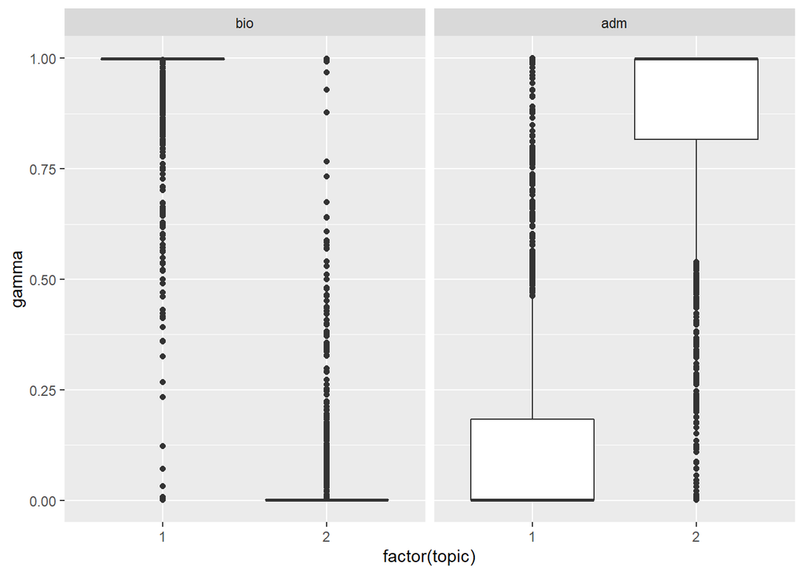

```r
docu_gamma %>%
  mutate(subject = reorder(subject, gamma * topic)) %>%
  ggplot(aes(factor(topic), gamma)) +
  geom_boxplot() +
  facet_wrap(~ subject)
```

위의 그림에서 보면 box plot이 극명하게 갈림을 확인 할수 있다.

#### 2-1: Bonus

어느 문서에서 극명하게 갈리고 있는지를 확인해보자.

```r
docu_classifications <- docu_gamma %>%
  group_by(subject, document) %>%
  top_n(1, gamma) %>%
  ungroup()

subject_topics <- docu_classifications %>%
  count(subject, topic) %>%
  group_by(subject) %>%
  top_n(1, n) %>%
  ungroup() %>%
  transmute(consensus = subject, topic)

subject_topics  #topic classification through the lda
```

```
## # A tibble: 2 x 2
##   consensus topic
##   <chr>     <int>
## 1 adm           2
## 2 bio           1
```

lda를 통해 topic이 어떻게 분류되었는지를 확인할 수 있다.

```r
wrong_docu <- docu_classifications %>%
  inner_join(subject_topics, by = "topic") %>%
  filter(subject != consensus) %>%
  count(subject, consensus,document) %>%
  ungroup() %>%
  arrange(desc(n))

wrong_docu
```

```
## # A tibble: 186 x 4
##    subject consensus document                                             n
##    <chr>   <chr>     <chr>                                            <int>
##  1 adm     bio       "3.5-Year Monitoring of 225 GHz Opacity at the ~     1
##  2 adm     bio       "A biological model of scabies infection dynami~     1
##  3 adm     bio       "A Brief Comment on Post inversion formula for ~     1
##  4 adm     bio       "A Conversation with James Hannan              ~     1
##  5 adm     bio       "A decompilation of the pi-calculus and its app~     1
##  6 adm     bio       "A flexible multidimensional rectangular mesh a~     1
##  7 adm     bio       "A Generator System of Invariant differential f~     1
##  8 adm     bio       "A Markov decision process approach to optimizi~     1
##  9 adm     bio       "A mathematical model of granulopoiesis incorpo~     1
## 10 adm     bio       "A Mathematical Programming Approach to the Fra~     1
## # ... with 176 more rows
```

잘못 분류된 문서들의 목록을 확인 할 수 있다.

```r
accuracy_docu_assign <- 1- sum(wrong_docu$n)/nrow(docu_classifications)
str_c("Documents & Topic Accuracy:",percent(accuracy_docu_assign),sep=' ')
```

```
## [1] "Documents & Topic Accuracy: 90.7%"
```

정확도는 위와 같다.

#### 2-2) Term & Topic

```r
assignments <- augment(data_lda, data = data_dtm)
assignments
```

```
## # A tibble: 106,497 x 4
##    document                                         term       count .topic
##    <chr>                                            <chr>      <dbl>  <dbl>
##  1 "adm::\"I ain't tellin' white folks nuthin\": A~ administr~     1      2
##  2 "adm::A biological model of scabies infection d~ administr~     2      1
##  3 "adm::A Brief Comparison of Two Enterprise-Clas~ administr~     1      2
##  4 "adm::A Comprehensive Assessment Strategy for P~ administr~     1      2
##  5 "adm::A Comprehensive Performance Analysis of P~ administr~     1      2
##  6 "adm::A Conversation with James Hannan         ~ administr~     1      2
##  7 "adm::A Cyberinfrastructure-based Approach to R~ administr~     1      2
##  8 "adm::A Digital Preservation Appliance Based on~ administr~     1      2
##  9 "adm::A Distributed Multi Agents Based Platform~ administr~     1      2
## 10 "adm::A flexible multidimensional rectangular m~ administr~     1      2
## # ... with 106,487 more rows
```

```r
assignments <- assignments %>%
  separate(document, c("subject", "document"), sep = "::", convert =T) %>%
  inner_join(subject_topics, by = c(".topic" = "topic"))
print(assignments, n = 7)
```

```
## # A tibble: 106,497 x 6
##   subject document                          term     count .topic consensus
##   <chr>   <chr>                             <chr>    <dbl>  <dbl> <chr>
## 1 adm     "\"I ain't tellin' white folks n~ adminis~     1      2 adm
## 2 adm     "A biological model of scabies i~ adminis~     2      1 bio
## 3 adm     "A Brief Comparison of Two Enter~ adminis~     1      2 adm
## 4 adm     "A Comprehensive Assessment Stra~ adminis~     1      2 adm
## 5 adm     "A Comprehensive Performance Ana~ adminis~     1      2 adm
## 6 adm     "A Conversation with James Hanna~ adminis~     1      2 adm
## 7 adm     "A Cyberinfrastructure-based App~ adminis~     1      2 adm
## # ... with 1.065e+05 more rows
```

subject와 consensus가 다른 것의 비율을 살필 예정이다.

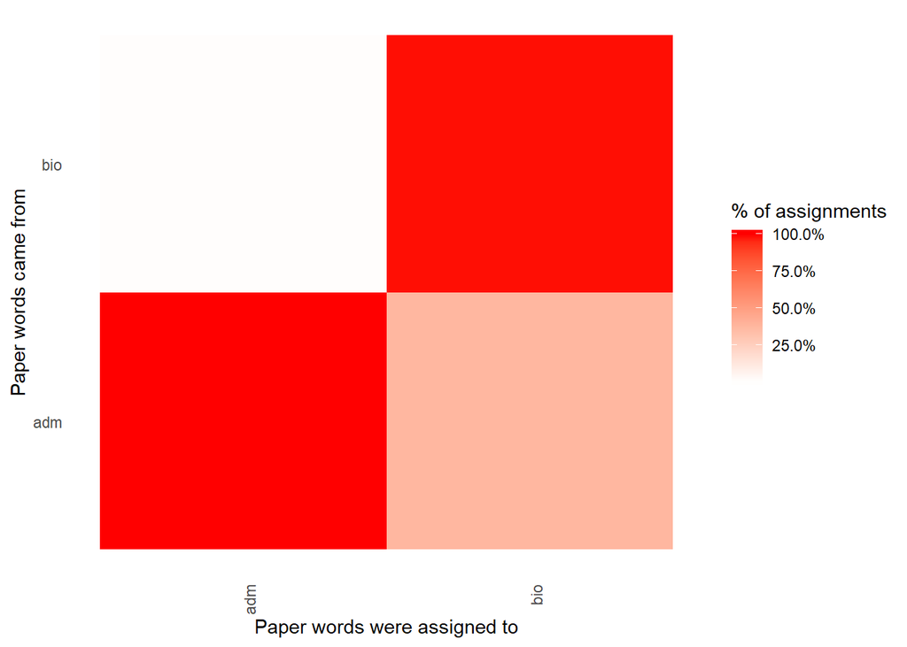

```r
assignments %>%
  count(subject,document, consensus, wt = count) %>%
  group_by(document) %>%
  mutate(percent = n / sum(n)) %>%
  ggplot(aes(consensus, subject, fill = percent)) +
  geom_tile() +
  scale_fill_gradient2(high = "red", label = percent_format()) +
  theme_minimal() +
  theme(axis.text.x = element_text(angle = 90, hjust = 1),
        panel.grid = element_blank()) +
  labs(x = "Paper words were assigned to",
       y = "Paper words came from",
       fill = "% of assignments")
```

heatmap으로 보면 위와 같다.

```r
wrong_words <- assignments %>%
  filter(subject != consensus) %>%
  count(subject, consensus, term, wt = count) %>%
  ungroup() %>%
  arrange(desc(n))

accuracy_word_assign <- 1- sum(wrong_words$n)/nrow(assignments)
str_c("Words & Topic Accuracy:",percent(accuracy_word_assign),sep=' ')
```

```
## [1] "Words & Topic Accuracy: 84.1%"
```

정확도는 위와 같다.

## 3. (Document Classification) Train LDA to the pooled data with 10 topics, and apply logistic regression, random forest, and SVM. Then compare their performance.

```r
data_lda2 <- LDA(data_dtm, k = 10,
                control = list(seed = 1234))
data_gamma2 <- tidy(data_lda2, matrix = "gamma") %>%
  mutate(document = reorder(document, gamma * topic)) %>%
  spread(topic,gamma)
docu_gamma2 <- data_gamma2 %>%
  separate(document, c("subject", "document"), sep = "::", convert = T) %>%
  mutate(subject=as.factor(subject))
```

```r
f <- as.formula(paste('subject','~',str_c(paste0("`",1:10,"`"),collapse = '+')))
```

2-3에서 사용할 데이터를 목적에 맞게 추출하고 정비하였다. lda를 10개의 topic으로 나누어 보고, 이때 각 topic은 변수이다. 우리는 documnet & topic 에서 얻어지는 gamma값(확률) 을 사용할 계획이다.

#### 3-1) Logistic

```r
#logistic
logistic <- glm(f, data=docu_gamma2, family = 'binomial')
pred_logistic <- as.factor(ifelse(logistic$fitted.values >=0.5 , 'bio','adm'))
confusion_logistic <- confusionMatrix(pred_logistic,docu_gamma2$subject)
confusion_logistic
```

```
## Confusion Matrix and Statistics
##
##           Reference
## Prediction adm bio
##        adm 742  55
##        bio 258 945
##
##                Accuracy : 0.8435
##                  95% CI : (0.8268, 0.8592)
##     No Information Rate : 0.5
##     P-Value [Acc > NIR] : < 2.2e-16
##
##                   Kappa : 0.687
##
##  Mcnemar's Test P-Value : < 2.2e-16
##
##             Sensitivity : 0.7420
##             Specificity : 0.9450
##          Pos Pred Value : 0.9310
##          Neg Pred Value : 0.7855
##              Prevalence : 0.5000
##          Detection Rate : 0.3710
##    Detection Prevalence : 0.3985
##       Balanced Accuracy : 0.8435
##
##        'Positive' Class : adm
##
```

Logistic의 오분류표는 위와 같다.

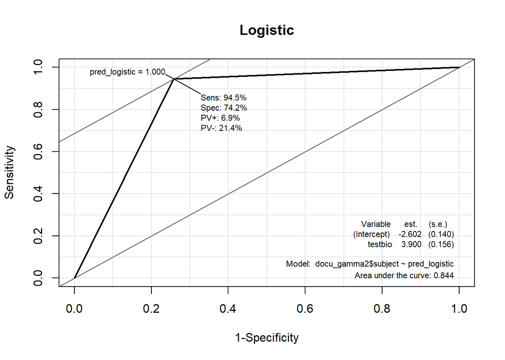

```r
ROC(test=pred_logistic, stat=docu_gamma2$subject, plot="ROC", AUC=T, main="Logistic")
```

Logistic의 ROC곡선은 위와 같다.

#### 3-2) SVM

```r
#svm
support_vector_machine <- svm(f,data=docu_gamma2)
pred_svm <- as.factor(support_vector_machine$fitted)
confusion_svm <- confusionMatrix(pred_svm,docu_gamma2$subject)
confusion_svm
```

```
## Confusion Matrix and Statistics
##
##           Reference
## Prediction adm bio
##        adm 735  39
##        bio 265 961
##
##                Accuracy : 0.848
##                  95% CI : (0.8315, 0.8635)
##     No Information Rate : 0.5
##     P-Value [Acc > NIR] : < 2.2e-16
##
##                   Kappa : 0.696
##
##  Mcnemar's Test P-Value : < 2.2e-16
##
##             Sensitivity : 0.7350
##             Specificity : 0.9610
##          Pos Pred Value : 0.9496
##          Neg Pred Value : 0.7838
##              Prevalence : 0.5000
##          Detection Rate : 0.3675
##    Detection Prevalence : 0.3870
##       Balanced Accuracy : 0.8480
##
##        'Positive' Class : adm
##
```

SVM의 오분류표는 위와 같다.

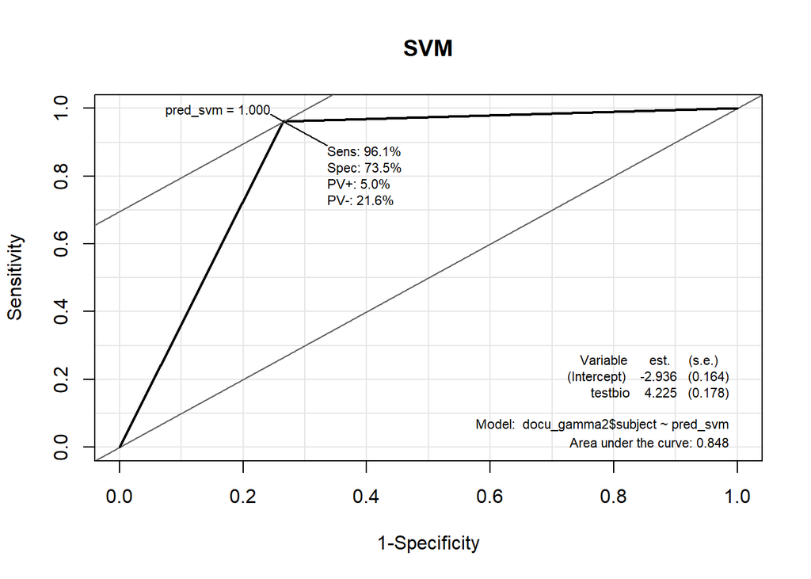

```r
ROC(test=pred_svm, stat=docu_gamma2$subject, plot="ROC", AUC=T, main="SVM")
```

SVM의 ROC곡선은 위와 같다.

#### 3-3) Random Forest

```r
#random forest
dat_rf <- docu_gamma2 %>%
  rename(factor1=`1`,factor2=`2`,factor3=`3`,factor4=`4`,factor5=`5`,
         factor6=`6`,factor7=`7`,factor8=`8`,factor9=`9`,factor10=`10`)
set.seed(1234)

rf = randomForest(subject~factor1+factor2+factor3+factor4+factor5+factor6+
                    factor7+factor8+factor9+factor10, data=dat_rf,mtry = floor(sqrt(10)))
pred_rf <- rf$predicted
confusion_rf <- confusionMatrix(pred_rf,docu_gamma2$subject)
confusion_rf
```

```
## Confusion Matrix and Statistics
##
##           Reference
## Prediction adm bio
##        adm 874 106
##        bio 126 894
##
##                Accuracy : 0.884
##                  95% CI : (0.8691, 0.8977)
##     No Information Rate : 0.5
##     P-Value [Acc > NIR] : <2e-16
##
##                   Kappa : 0.768
##
##  Mcnemar's Test P-Value : 0.2122
##
##             Sensitivity : 0.8740
##             Specificity : 0.8940
##          Pos Pred Value : 0.8918
##          Neg Pred Value : 0.8765
##              Prevalence : 0.5000
##          Detection Rate : 0.4370
##    Detection Prevalence : 0.4900
##       Balanced Accuracy : 0.8840
##
##        'Positive' Class : adm
##
```

Random Forest의 오분류표는 위와 같다.

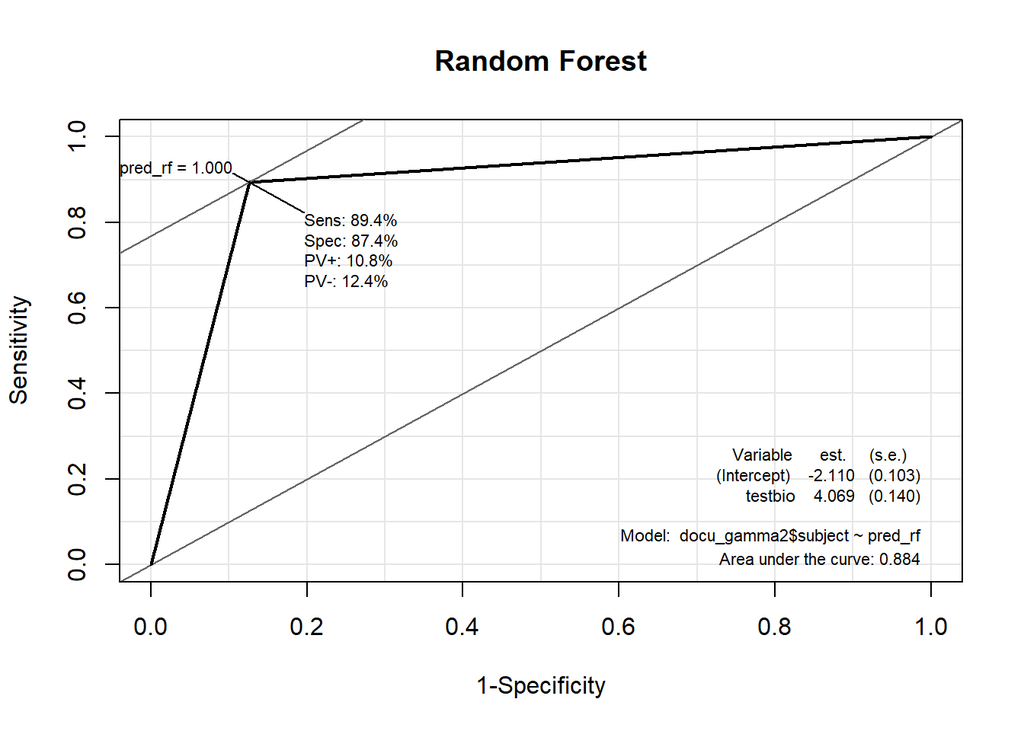

```r
ROC(test=pred_rf, stat=docu_gamma2$subject, plot="ROC", AUC=T, main="Random Forest")
```

Random Forest의 ROC곡선은 위와 같다.

세개의 차이는 대동소이하며, Random Forest에서 AUC값이 가장 큼을 확인할 수 있다. 또한 정확도를 봐도 무방하며, $F1 = \frac{2}{ \frac{1}{Precision} + \frac{1}{Recall}}$의 계산을 통해 모형비교를 해도 좋다.

그 F1값은 아래와 같다.

```r
#F1 score
f1_logistic <- round(F1_Score(docu_gamma2$subject,pred_logistic),3)
f1_svm <- round(F1_Score(docu_gamma2$subject,pred_svm),3)
f1_rf <- round(F1_Score(docu_gamma2$subject,pred_rf),3)

X <- cbind(f1_logistic,f1_svm,f1_rf)
rownames(X) <- "F1 Score"
colnames(X) <- c('Logistic','SVM','Random_Forest')
X
```

```
##          Logistic   SVM Random_Forest
## F1 Score    0.826 0.829         0.883
```